# EEMB 146 Final Report: Going With the Flow: Vegetation Sapflow on Pacific Atolls

Talula Wilmot

2025-03-10

## Abstract

This study investigates the transpiration rates of two tree species, Cocos nucifera (coconut palm) and Pisonia grandis, on the atoll of Tetiaroa in French Polynesia. The aim is to compare their average sap flow and explore the influence of diameter at breast height (DBH) on transpiration rates. Data was collected over a six-month period across three motu using sap flow sensors to quantitatively track average transpiration, then analyzed in R. Results from a two-sample t-test showed no significant difference in mean sap flow between the two species, while a linear regression revealed that DBH was not a significant predictor of sap flow. This research contributes to understanding water consumption by these species, with implications for managing coconut palms and native vegetation on the atoll.

## Introduction

The atoll of Tetiaroa, located in French Polynesia, is home to a unique and diverse ecosystem that includes various tree species. Understanding the factors that influence the transpiration rates of these species is essential for evaluating their water use efficiency and their role in the island’s ecological balance. The data that I have presented in this analysis is a combination of many measurements, the focus being average sap flow across the 6 month deployment period, which is essentially the average transpiration rate of water within the trunk. The data was collected across 3 motu (islands within the atoll) and 5 plant species, for a total of 96 raw observations. Out of these species we are only focusing on; Coco Nucifera and Pisonia Grandis, while specifically looking at their relationship to each other as well as diameter at breast height, (3 variables). Tetiaroa was formerly a coconut plantation that was then bought by the actor Marlon Brando in 1966. Since its purchase it has transitioned to a private resort/scientific research center. The coconut palms, while a vast resource for the polynesian people, have become invasive on the atoll altering much of the natural forest including overtaking the native Pisonia Grandis.

Thus far some extensive research has been conducted on one of the atoll species, Coco Nucifera in which it was found that coconut palms use between 93-160 L of water per day (Roupsard et al., 2006). However this study was not conducted on an atoll but rather a volcanic Pacific Island and used less sensitive measurements to obtain uptake rates, than the Sap Flow sensors used in our experiment. Sap Flow sensors are constructed on the UCSB campus under the guidance of Michael Burnett, a current PHD student, and a team of undergraduate assistants including myself. They are a three part system that is inserted in the trunk in which a heater probe between two temperature sensor probes sends out a heat pulse vaporizing the water within the trunk which is then tracked by the temperature probes and logged in the memory of the device. The design of these sensors is based on the research of Beslity et al. 2022, who initially constructed a self made version of these commercially available devices. Additional studies have been conducted measuring the sap flow of Pisonia Trees in which it was found that the use between 14-67 liters per day (Krauss et al.2015), but again this study used heat dissipation probes which are less accurate than sap flow probes and looked at smaller trees relative to what is present on Tetiaroa. These studies while informative to our experimental design demonstrate a gap in the knowledge of how this ecosystem functions and allocates water. The data that will be explored in this paper was collected by myself, my graduate student mentor Michael Burnett and a team of fellow undergraduates from the atoll of Tetiaroa in French Polynesia. This data set and following studies have not yet been published as the experiment is still ongoing. The final set of data will be collected in the summer of 2025 in which it will be analyzed, much of it being the basis of Mike Burnett’s PHD thesis. It is predicted that reverting coconut plantations to a coral islands “natural state” significantly increases freshwater volume (Comte et al., 2014) but there have not been any concrete studies measuring the quantitative water use of vegetation on atolls, which is what this study aims to do.

The question that this analysis aims to answer is; Do coconut palms transpire more water than the native Pisonia Grandis trees, and does diameter at breast height influence the rate of said transpiration? The hypothesis is that a larger DBH (diameter at breast height) is related to higher rates of transpiration, and coconut palms use significantly more water on average than the Pisonia trees. By exploring the physiological responses of these trees, this research contributes to a broader understanding of plant-water relations in tropical island and groundwater dependent ecosystems.

## Exploratory Data Analysis

After establishing normality in the data set NA’s produced from the transformation were removed. The data was then subset by species to include only Pisonia Grandis and Cocos Nucifera. We are primarily interested in whether the Coconut Palms transpire more water than the Pisonia Grandis. This is because coconut palms while providing key resources to the Polynesian people, including food, medicine, and timber, have become invasive as they’ve moved past their native range on the coastline and overtaken native forests including those made up of Pisonia Grandis. This has left only a few Motu within the atoll still possessing Pisonia. Because atolls are completely ground water dependent ecosystems having information on the transpiration rates and overall water consumption of different species could provide key management insights. The plot used to test a relationship between “Diameter at Breast Height” and “Average Sapflow” was a scatter plot fit with a regression line, to see if average sapflow can be predicted by diameter at breast height across both species of interest (Fig. 1). To see if there was a significant difference in mean sapflow between Cocos Nuciefra and Pisonia Grandis a box plot was used (Fig. 2). Colors were assigned to both plots based on species to more easily distinguish variations in spread and mean.

The data transformation performed on the y-variable that established normality was a square root transformation on the Avg.Sapflow. A log transformation was also performed previously but did not increase the normality of the y-variable (see appendix 1). Square rooting produced some NA’s which were filtered out of the final dataset. The data are normally distributed with a Shapiro-Wilk test for normality producing a p-value of 0.5135, and a qqPlot showing no outliers outside of the 95% confidence bands, allowing us to accept the null hypothesis. There is a concentration around an average sapflow of 1cm per hour, with no large outliers, that would cause a skew in the data.

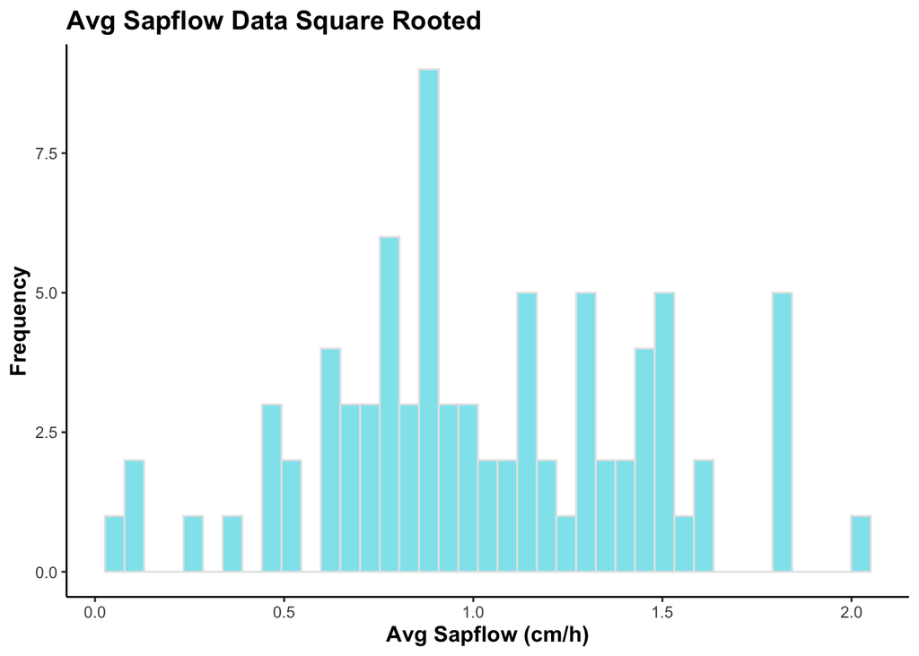

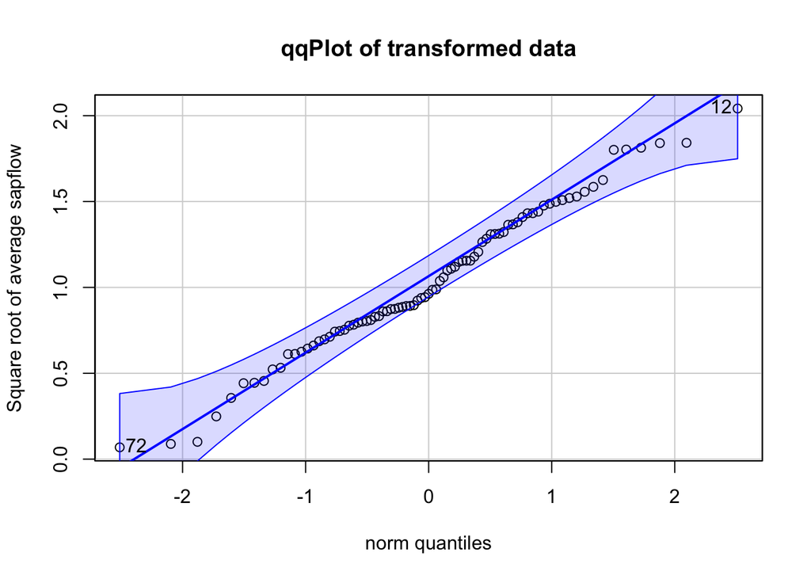

```
## [1] 12 72
```

```
##
##  Shapiro-Wilk normality test
##
## data:  species_filtered$sqrt_avg_sapflow
## W = 0.98608, p-value = 0.5135
```

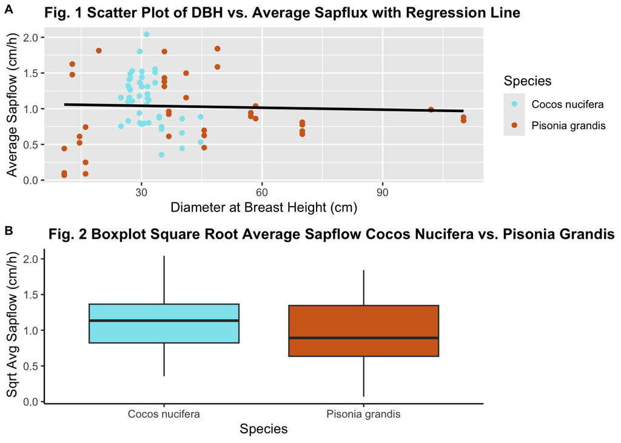

## Statistical Methods

### Test 1: Comparing the means of Square root of Average Sap Flow between species Cocos Nucifera and Pisonia Grandis.

In order to test if the means of average sap flow were different between our species of interest a two sample t-test was performed. Before the t-test, a levene.test was done to see if the square root of average sap flows had equal variance between species (Appendix 1). A p-value below our 0.05 alpha significance level tells us that the species groups do not have equal variance between them, however a p-value larger than this allows us to accept the null hypothesis that variance is equal. After running a levene.test on the data a p-value of 0.1362 was returned (Appendix 1). Once equal variance was established a two sample t-test could be conducted (Appendix 1). The null hypothesis for this test was that there is no difference between the mean square root average sap flow between Cocos Nucifera and Pisonia Grandis. The alternative hypothesis was that there is a significant difference between the mean square root average sap flow between Cocos Nucifera and Pisonia Grandis.

$H_0: \mu_d= 0$

$H_a: \mu_d \ne 0$

A p-value below our 0.05 alpha significance level tells us that the means are significantly different from each other. A p-value greater than our alpha significance level allows us to accept the null hypothesis that there is no difference in the means for average sap flow between Coconut and Pisonia.

### Test 2: Regression, Squareroot Average Sapflow and Diameter at Breast Height

$H_0: \beta = 0$

$H_a: \beta \ne 0$

The assumptions of a regression are that Y is equally distributed with equal variance for all values of X. In order to establish the normality and equal variance of the data a plot was created using a linear model of the data (See Appendix 1). The “Residuals vs. Fitted” plot was analyzed for equal variance while the “Q-Q Residuals” plot was analyzed for normality. The “Residuals vs. Fitted” plot showed a moderate decline toward the high end of the x-axis as well as slightly greater variance of residuals but followed a straight line until that point and showed no specific pattern or shape. For the sake of this experiment equal variance can be established. The “Q-Q Residuals” plot follows a linear trend with no major outliers so normality can also be established. After these assumptions are met a linear model can be produced to give us an estimate for the equation of the regression line (See Appendix 1). The p-value output tells us whether we can accept or reject the null hypothesis and whether diameter at breast height is a significant predictor of sap flow if it is below our 0.05 alpha significance level. The multiple R-squared value from this output also tells us the amount of variation in sap flow that can be explained by diameter at breast height between our two species of interest, Cocos nucifera and Pisonia grandis.

## Results

### Test 1

The results of test 1 allow us to accept the null hypothesis that there is no significant difference between the mean sapflow of Pisonia Grandis and Coco Nucifera. The Levene test allowed us to meet the assumptions of the two sample t-test that there was equal variance between the two groups as the p-value was 0.1362. Following this test a two sample t-test was performed resulting in a p-value of 0.1004, with a test statistic of 1.6618. This again allows us to accept the null hypothesis at a 0.05 significance level. The 95 percent confidence interval for this test is -0.03078684, 0.34288321. Since the confidence interval encompasses zero we see that there is likely no signifcant difference in the average amount of water taken up by each species. A summary of the results is shown in Table 1.

Table 1. Test 1

[output not shown]

### Test 2

The results of our regression again allow us to accept the null hypothesis that slope of the line calculated for the linear model of Diameter at breast height vs. Square root of average sapflow is not significantly different from zero. The p-value of the regression was 0.698400, with 81 degrees of freedom. The F-statistic was 0.1513, and the R-squared value was 0.001864. These results show that the slope was not significant, meaning that there was not a strong relationship between DBH and Sapflow either positively or negatively. Additionally DBH was not an accurate predictor of sapflow within our species of interest. This means that we could not solely use DBH to determine what influences the transpiration rate of vegetation on atolls, and there must be other confounding factors. A summary of results can be seen in Table 2.

Table 2. Results Test 2

|  | Regression |
| --- | --- |
| p-value | 0.698400 |
| df | 81.000000 |
| F-statistic | 0.151300 |
| R squared | 0.001864 |

## Discussion

Our study aimed to compare the transpiration rates of Pisonia Grandis and Coco Nucifera, two species present on the atoll of Tetiaroa in French Polynesia. Based on our analysis we can conclude that there is no significant difference in the mean uptake rate of water between Pisonia Grandis and Coco Nucifera (Table 1.) This counters previous physiological findings in which it was seen that Pisonia transpire significantly less water than coconut palms (Krauss et al. 2015). At the scale of this experiment it would seem that the invasive palms do not take significantly more water than then native species and thus may not be an issue in managing groundwater resources past the fact that the excess of coconut palms increases the shear biomass of transpiring vegetation. Additionally, Test 2 showed that the regression line calculated by the linear model was not significantly different from 0, demonstrating that diameter at breast height for both our species of interest was not an accurate predictor of average sap flow. This countered our hypothesis and the basic assumption that a larger tree would uptake more water to accommodate the increase in foliage. This result suggests that DBH is not a straightforward indicator of water use, indicating the need for more complex modeling or different factors in predicting transpiration. Possible points of analysis that already exist within our data set could be tree height, or the Motu which the tree is located on.

While these findings suggest that coconut palms do not transpire significantly more water than pisonia, these are only preliminary results and there is still over a year’s worth of data to be collected and analyzed. Furthermore this data was collected from January-June, while the wet season in French Polynesia typically spans November to April. This would mean that the transpiration rate was being measured during a particularly wet time when the vegetation may not need to access significant groundwater supply due to the constant saturation of topsoil. Had this data set spanned an entire year there may be a clearer picture of how the trees responded to drier conditions, and potentially show a greater difference in their uptake.

As we see in Fig.1 many of these trees were quite large, some reaching over 100 cm in diameter, while each one was only fitted with 1 sap flow sensor, containing needles between 2 - 4 inches long. This could lead to limitations in our measurements as we are assuming that the distribution of xylem is uniform throughout the entire trunk. If I were to improve this study I would take a smaller sample of both species and insert multiple sensors around the entire circumference of the trunk, these measurements could then be averaged and used to determine a more accurate number for centimeters of sap flow per hour. Overall, while our results do not show significance across either of our hypotheses, that a larger DBH (diameter at breast height) is related to higher rates of transpiration, and coconut palms use significantly more water on average than the Pisonia trees, there are many ways in which we could improve the confidence of this study, and with a longer time frame and further testing we may see different outcomes.

I am currently working on a project in which we are taking 3 palms and inserting 8 sap flow sensors around the trunk with the hypothesis that there is a certain area in the trunk in which xylem sacks are concentrated, leading to more variable transpiration measurement.

## References

### Papers:

Beslity, J., Shaw, S. B., Drake, J. E., Fridley, J., Stella, J. C., Stark, J., & Singh, K. (2022). A low cost, low power sap flux device for distributed and intensive monitoring of tree transpiration. HardwareX, 12, e00351. https://doi.org/10.1016/j.ohx.2022.e00351

Comte, J.-C., Join, J.-L., Banton, O., & Nicolini, E. (2014). Modelling the response of fresh groundwater to climate and vegetation changes in coral islands. Hydrogeology Journal, 22(8), 1905–1920. https://doi.org/10.1007/s10040-014-1160-y

Krauss, K. W., Duberstein, J. A., Cormier, N., Young, H. S., & Hathaway, S. A. (2015). Proximity to encroaching coconut palm limits native forest water use and persistence on a Pacific atoll. Ecohydrology, 8(8), 1514–1524. https://doi.org/10.1002/eco.1601

Roupsard, O., Bonnefond, J.-M., Irvine, M., Berbigier, P., Nouvellon, Y., Dauzat, J., Taga, S., Hamel, O., Jourdan, C., Saint-André, L., Mialet-Serra, I., Labouisse, J.-P., Epron, D., Joffre, R., Braconnier, S., Rouzière, A., Navarro, M., & Bouillet, J.-P. (2006). Partitioning energy and evapo-transpiration above and below a tropical palm canopy. Agricultural and Forest Meteorology, 139(3–4), 252–268. https://doi.org/10.1016/j.agrformet.2006.07.006

### Packages:

```
##  [1] ".GlobalEnv"        "package:knitr"     "package:cowplot"
##  [4] "package:multcomp"  "package:TH.data"   "package:MASS"
##  [7] "package:survival"  "package:mvtnorm"   "package:car"
## [10] "package:carData"   "package:psych"     "package:lubridate"
## [13] "package:forcats"   "package:stringr"   "package:dplyr"
## [16] "package:purrr"     "package:readr"     "package:tidyr"
## [19] "package:tibble"    "package:ggplot2"   "package:tidyverse"
## [22] "package:stats"     "package:graphics"  "package:grDevices"
## [25] "package:utils"     "package:datasets"  "package:methods"
## [28] "Autoloads"         "package:base"
```

### Sapflow Data:

Michael Burnett, personal communication, June 2024 (Ongoing)

## Appendix

### Section 1: Exploratory data analysis

```r
# Cleaning Data
sapflow <- read.csv("~/Desktop/Biometry/Final Project /tetiaroa-sapflow-ESA2024-workbook-2024-08-02.csv")
transformed_sapflow <- sapflow %>% mutate(sqrt_avg_sapflow = sqrt(Avg.SFD.cm.h))
clean_sapflow <- transformed_sapflow %>%
 filter(!is.na(sqrt_avg_sapflow))

species_filtered <- clean_sapflow %>%filter(Species %in% c("Cocos nucifera", "Pisonia grandis"))
write.csv(species_filtered, "Cleansapflow.csv", row.names = TRUE)
```

[figure not shown]

```r
## data transformation 1
log_sapflow <- sapflow %>% mutate(log_avg_sapflow = log(Avg.SFD.cm.h))
ggplot(log_sapflow, aes(x= log_avg_sapflow)) + #histogram of log data
  geom_histogram( bins = 39, fill = "pink", color = "grey90") +
  labs (title = "Avg Sapflow Data Square Rooted", x= "Avg Sapflow (cm/h)", y= "Frequency") + #informative title and x, y labels
  theme_classic()+
  theme(axis.title = element_text(face = "bold", size = 12), title = element_text(face = "bold", size = 12 )) #bold 12 size font
```

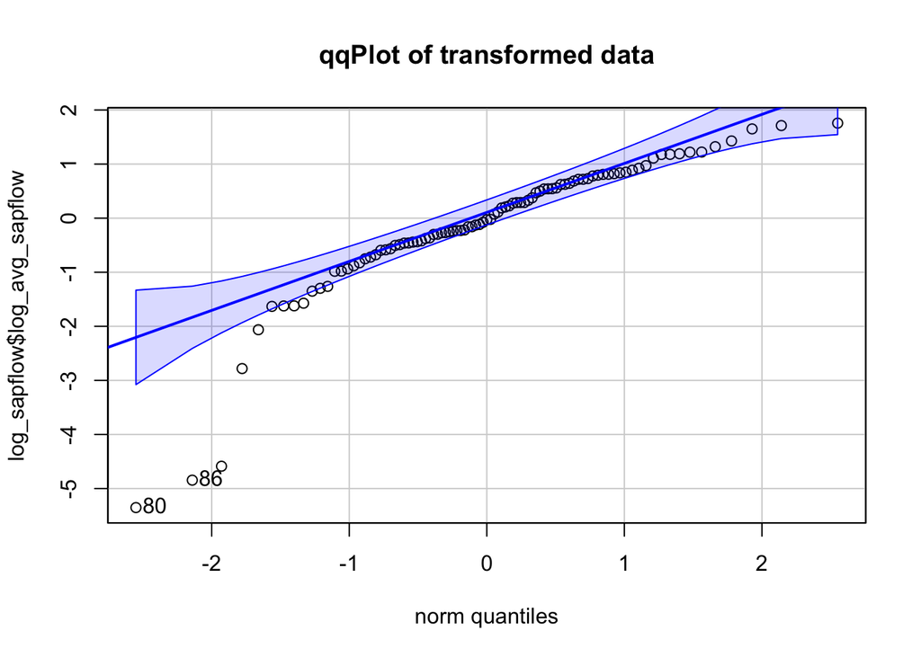

```
## [1] 80 86
```

```r
qqPlot(log_sapflow$log_avg_sapflow, main= "qqPlot of transformed data") #qqPlot of log data to test for normality
```

```r
shapiro.test(log_sapflow$log_avg_sapflow) #test for normality
```

```
##
##  Shapiro-Wilk normality test
##
## data:  log_sapflow$log_avg_sapflow
## W = 0.84657, p-value = 2.167e-08
```

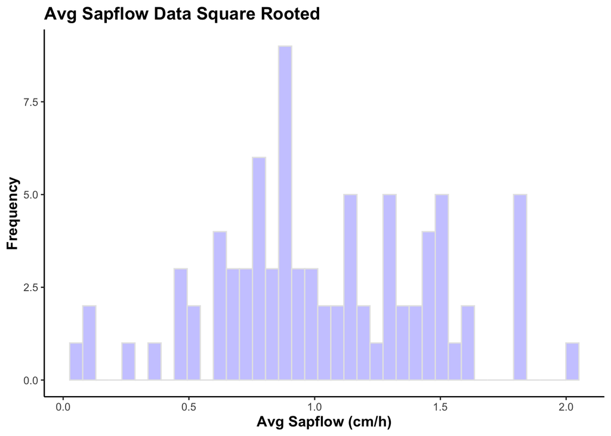

```r
## data transformation 2
ggplot(species_filtered, aes(x= sqrt_avg_sapflow)) + #historgram of square root data
  geom_histogram( bins = 39, fill = "#CCCCFF", color = "grey90") +
  labs (title = "Avg Sapflow Data Square Rooted", x= "Avg Sapflow (cm/h)", y= "Frequency") + #informative title and x, y labels
  theme_classic()+
  theme(axis.title = element_text(face = "bold", size = 12), title = element_text(face = "bold", size = 12 )) #bold 12 size font
```

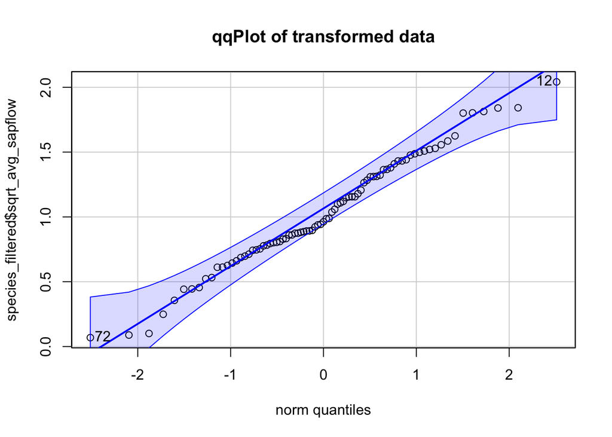

```
## [1] 12 72
```

```r
qqPlot(species_filtered$sqrt_avg_sapflow, main= "qqPlot of transformed data") #qqPlot of squareroot data to test for normality
```

```r
shapiro.test(species_filtered$sqrt_avg_sapflow) #test for normality
```

```
##
##  Shapiro-Wilk normality test
##
## data:  species_filtered$sqrt_avg_sapflow
## W = 0.98608, p-value = 0.5135
```

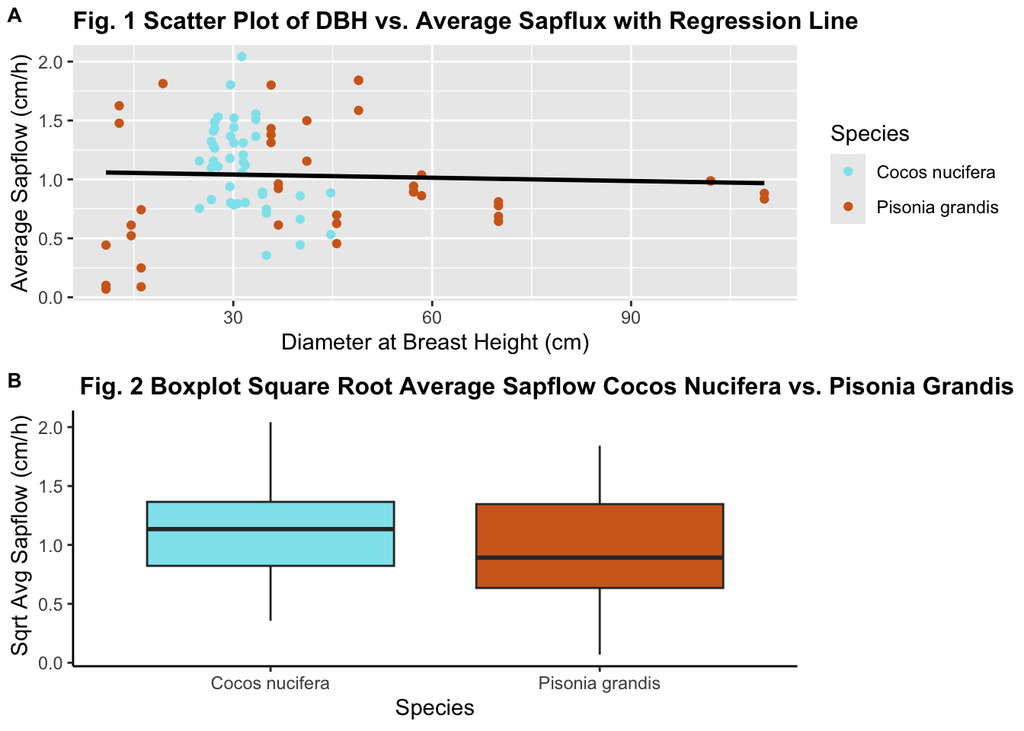

```r
## Exploratory plots
group_colors <- c("Cocos nucifera" ="cadetblue2", "Pisonia grandis" ="chocolate") #establish colors based on species
regression <- ggplot(species_filtered, aes(x = DBH.cm, y = sqrt_avg_sapflow)) + #create a scatterplot using DBH as x-axis and sqrt_avg_sapflow as y-axis
  geom_point(aes(col = Species), pch = 19) + #assign colors based on species of tree
  scale_color_manual(values = group_colors) +
  geom_smooth(method = "lm", se = FALSE, color = "black") + #create a line in the scatterplot using a linear model of the data to establish regression line
  labs(
    title = "Fig. 1 Scatter Plot of DBH vs. Average Sapflux with Regression Line",
    x = "Diameter at Breast Height (cm)",
    y = "Average Sapflow (cm/h)"
  ) + theme(plot.title = element_text(face ="bold", size = 12)) #appropriate labels, theme, and font size



boxplot <- ggplot(species_filtered, aes(x= Species, y= sqrt_avg_sapflow)) + #create a boxplot of our two species of interest against square root of average sapflow to assess differences in means and spread
  geom_boxplot(fill= c("cadetblue2", "chocolate"))+ #give them appropriate colors matching with figure 1
  theme_classic() + #plain background theme
  labs (title = " Fig. 2 Boxplot Square Root Average Sapflow Cocos Nucifera vs. Pisonia Grandis", x= "Species", y= " Sqrt Avg Sapflow (cm/h)")  +
theme(plot.title = element_text(face = "bold", size = 12))
plot_grid(regression, boxplot, ncol = 1, align = "v", labels = "AUTO", label_size= 10) #arrange the plots in the same field
```

### Section 2: Statistical methods

## Test 1

```r
#Comparing Means between Species
leveneTest(sqrt_avg_sapflow ~ Species, data = species_filtered) #test for equal variance
```

```
## Levene's Test for Homogeneity of Variance (center = median)
##       Df F value Pr(>F)
## group  1   2.265 0.1362
##       81
```

```r
Cocos_nucifera = filter(species_filtered, Species == "Cocos nucifera") #separate species into two seperate data frames to be compared
Pisonia_grandis = filter(species_filtered, Species == "Pisonia grandis")
t.test(Cocos_nucifera$sqrt_avg_sapflow, Pisonia_grandis$sqrt_avg_sapflow, var.equal = TRUE)
```

```
##
##  Two Sample t-test
##
## data:  Cocos_nucifera$sqrt_avg_sapflow and Pisonia_grandis$sqrt_avg_sapflow
## t = 1.6618, df = 81, p-value = 0.1004
## alternative hypothesis: true difference in means is not equal to 0
## 95 percent confidence interval:
##  -0.03078684  0.34288321
## sample estimates:
## mean of x mean of y
## 1.1073967 0.9513485
```

```r
## nice plot displaying the results
result1 <- c(0.1362, 82, 2.265)
result2 <- c(0.1004, 81, 1.6618)

row_labels <- c("p-value", "df", "test statistic")
table <- data.frame( result1, result2, row.names = row_labels )
kable(table, caption = " Table 1. Test 1", col.names = c("Levene Test", "Two Sample T-Test"))
```

Table 1. Test 1

[output not shown]

## Test 2

```r
#Is the slope of the regression line significantly different from 0?
mod = lm(sqrt_avg_sapflow ~ DBH.cm, data = species_filtered)
summary(mod)
```

```
##
## Call:
## lm(formula = sqrt_avg_sapflow ~ DBH.cm, data = species_filtered)
##
## Residuals:
##      Min       1Q   Median       3Q      Max
## -0.98997 -0.27461 -0.07267  0.32591  1.00153
##
## Coefficients:
##               Estimate Std. Error t value Pr(>|t|)
## (Intercept)  1.0686127  0.1007669  10.605   <2e-16 ***
## DBH.cm      -0.0009095  0.0023386  -0.389    0.698
## ---
## Signif. codes:  0 '***' 0.001 '**' 0.01 '*' 0.05 '.' 0.1 ' ' 1
##
## Residual standard error: 0.4338 on 81 degrees of freedom
## Multiple R-squared:  0.001864,   Adjusted R-squared:  -0.01046
## F-statistic: 0.1513 on 1 and 81 DF,  p-value: 0.6984
```

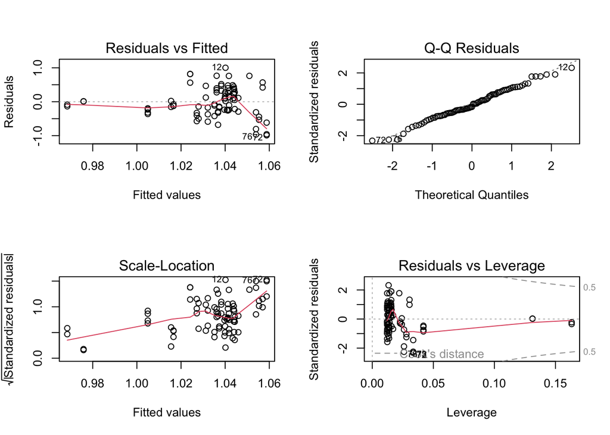

```r
#testing to meet requirements for running linear regression
par(mfrow = c(2,2))
plot(mod)
```

```r
result1 <- c(0.6984, 81, 0.1513, 0.001864)

row_labels <- c("p-value", "df", "F-statistic", "R squared")
table <- data.frame("Regression" = result1, row.names = row_labels )
kable(table, caption = "Table 2. Results Test 2")
```

Table 2. Results Test 2

|  | Regression |
| --- | --- |
| p-value | 0.698400 |
| df | 81.000000 |
| F-statistic | 0.151300 |
| R squared | 0.001864 |

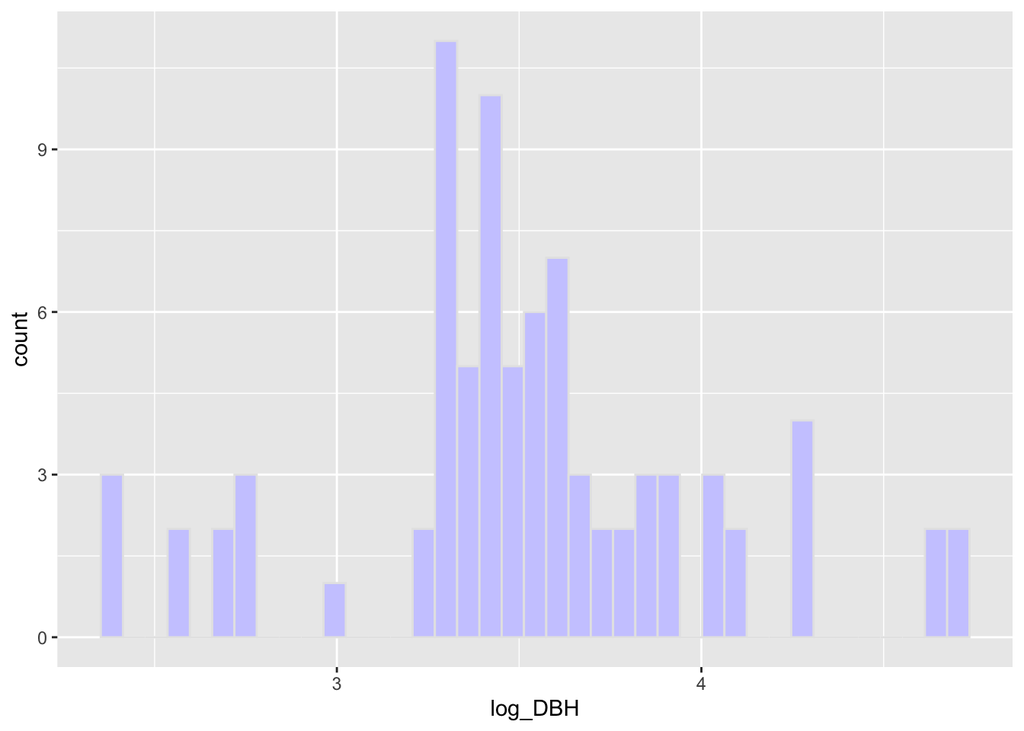

```r
# here I tried to manipulate numeric x-variable to make it normal but it would not normalize
species_filtered <- species_filtered %>% mutate(log_DBH = log(DBH.cm))
ggplot(species_filtered, aes(x= log_DBH)) +
  geom_histogram( bins = 39, fill = "#CCCCFF", color = "grey90")
```

```r
shapiro.test(species_filtered$log_DBH)
```

```
##
##  Shapiro-Wilk normality test
##
## data:  species_filtered$log_DBH
## W = 0.94732, p-value = 0.001935
```

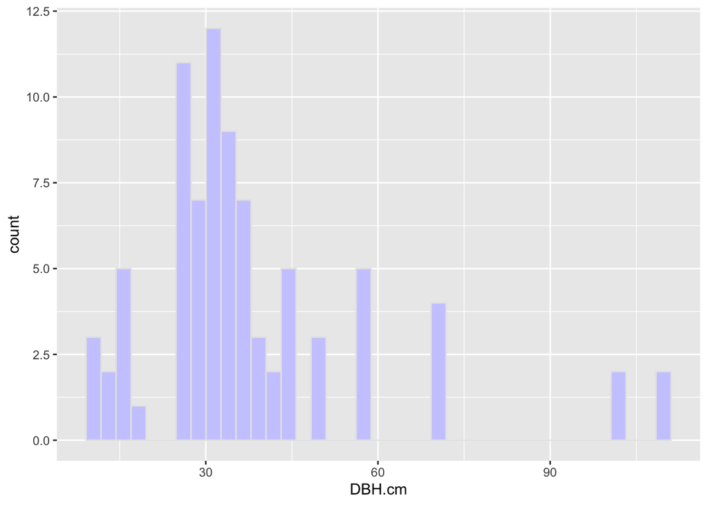

```r
ggplot(species_filtered, aes(x= DBH.cm)) +
  geom_histogram( bins = 39, fill = "#CCCCFF", color = "grey90")
```

```r
shapiro.test(species_filtered$DBH.cm)
```

```
##
##  Shapiro-Wilk normality test
##
## data:  species_filtered$DBH.cm
## W = 0.81348, p-value = 7.372e-09
```